# APPM2720 Homework 5

### Due next Monday February 8, 2016

The main point of this short assignment is to complete the questions from the R script **RintroProgramming2.R** from Week4

Following this script create a R function to smooth a dataset and apply this to the AudiA4 data. Please submit your R function and also a figure that answers the following question(s).

- Compare smooths for price against mileage in the `AudiA4` data. Does this look like a straight line? Try to add several different smooths to your scatterplot on the data.

### Extra credit!

- Do the smooths change if you use a subset of years? e.g. older cars or newer cars. What does this tell you about buying this kind of car?

### Notes

- Try some different spans (averging window width) for your smoother to balance detail verses smoothness. For the temperature data spans on the order of 2 to 10 years made sense. For the mileage variable these vary on the order of 10s of thousands of miles so use a span that adjsuts to these ranges.
- The smoothed results should make sense when plotted as points. But if your “x” values are not in increasing order the `lines` command can go a bit crazy joining points that are not next to each other. Here is a simple example of what I mean and the way to fix it.

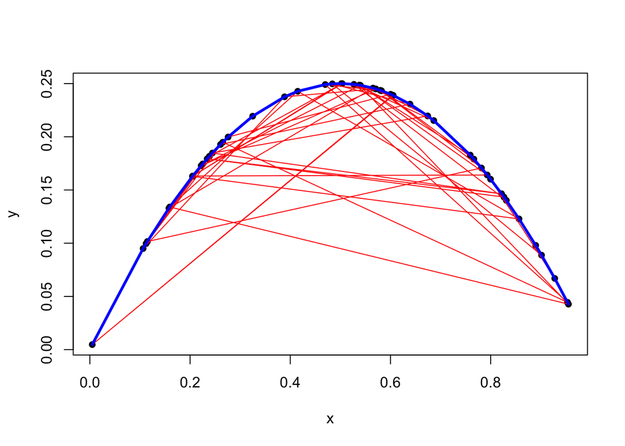

```r
# 50 points in [0,1] but in random order
set.seed( 221)
x<- runif( 50)
y<- x - x^2  # a simple quadratic curve in x
plot( x,y, pch=16)
# crazy lines
lines( x,y, col="red")
#use of the order function
ix<- order(x)
xSorted<- x[ix]
ySorted<- y[ix]
# nice lines
lines( xSorted, ySorted, col="blue", lwd=3)
```